# ML-Based Trading Strategy on Bitcoin

Quentin BORNE

2025-06-19

# 1 Introduction

Cryptocurrency markets are well known for their high volatility, strong non-linear dependencies, and limited predictability, making them an ideal field for testing advanced data-driven trading approaches. The primary goal of this project is to develop and evaluate a machine learning-based trading strategy for the Bitcoin perpetual futures market on Binance.

After performing a comprehensive data gathering and feature engineering process, I implemented a LightGBM model for next-day directional price prediction. The model’s output is then used to power a simple algorithmic trading strategy: going long or short with daily rebalancing and out-of-sample evaluation, using realistic assumptions for transaction costs and leverage.

The robustness and effectiveness of the model are assessed through systematic feature selection, hyperparameter tuning, and a thorough walk-forward backtest. Key performance metrics—such as return, volatility, and Sharpe ratio—are reported for various leverage scenarios and compared to a buy-and-hold benchmark. This approach not only measures the predictive power of the model but also its practical viability in a real trading environment.

# 2 Libraries

Libraries used for this project.

```r
if (!require("rvest")) install.packages("rvest"); library(rvest)
if (!require("dplyr")) install.packages("dplyr"); library(dplyr)
if (!require("knitr")) install.packages("knitr"); library(knitr)
if (!require("corrplot")) install.packages("corrplot"); library(corrplot)
if (!require("infotheo")) install.packages("infotheo"); library(infotheo)
if (!require("Matrix")) install.packages("Matrix"); library(Matrix)
if (!require("lightgbm")) install.packages("lightgbm"); library(lightgbm)
if (!require("caret")) install.packages("caret"); library(caret)
if (!require("foreach")) install.packages("foreach"); library(foreach)
if (!require("doParallel")) install.packages("doParallel"); library(doParallel)
if (!require("ggplot2")) install.packages("ggplot2"); library(ggplot2)
if (!require("tidyr")) install.packages("tidyr"); library(tidyr)
```

# 3 Data

## 3.1 Retrieving and Cleaning Data

The data was retrieved from the internet by using Python and then stored in a CSV file to be used here. I chose Python because I am more familiar with it for scrapping data. The Jupiter Notebook created for this purpose is titled “data_retrieving” and is included in the zip of this project.

You can find below a sample of the data retrieved. OHLC prices were retrieved from Binance BTC Perpetual Futures. Other data were gathered from different sources.

MACD_hist are daily histograms of the MACD. Google_trends are daily trends of “Bitcoin” on Google. FGI_score are daily scores of the Fear and Greed index. TIPS5Y are daily rates of an inflation-protected bond. US_rates are daily short term interest rate of US Treasury Bond.

For more clarification, please refer to the “data_retrieving” file.

The most important thing about data cleaning was handling NA values (particularly present for off days with macro data). To solve this, I used the “fillna(method=‘ffill’)” technique to carry forward the last known non-missing value.

```r
# Read the CSV file
data <- read.csv("C:/Users/quent/OneDrive/Documents/Etudes/M2 MQF/Classes/Track MQF/Machine learning with R/all_data.csv")

head(data, 2)
```

```
##         Date    Open    High  Low   Close  MACD_hist      RSI RSI_minus_50
## 1 2019-12-17 6887.48 6940.00 6550 6618.96 -20.557712 28.61228   -21.387717
## 2 2019-12-18 6618.96 7479.99 6427 7277.44   9.553813 47.48884    -2.511162
##   Google_trends FGI_score BTC_hashrate TIPS5Y   SP500  Nasdaq   Gold USD_index
## 1            97        23     90255692   1.85 3192.52 8823.36 1474.6     97.21
## 2           100        15     85774913   1.84 3191.14 8827.74 1472.6     97.41
##   US_rates   VIX
## 1    1.530 12.29
## 2    1.518 12.58
```

## 3.2 Features Engineering and Labeling

A part of the features engineering has already been performed in the “data_retrieving” file previously mentioned, such as computing the MACD_hist, RSI, and RSI_minus_50 from the daily Close prices.

The other part of the features engineering is performed below. The deltas of each potential features has been computed and added as new columns because we might need them to get rid of the persistence of the predictors given our label (to be confirmed later with the Auto Correlation analysis).

The chosen Label is the binary classification “1” if the BTC price of the next day went up, “0” if not. It is computed below and added as a new column (Daily_label). Of course, this project was coded to avoid any forward-looking bias.

```r
# Read the CSV file
data <- read.csv("C:/Users/quent/OneDrive/Documents/Etudes/M2 MQF/Classes/Track MQF/Machine learning with R/all_data.csv")

# Identify columns from MACD_hist to the end
start_col <- which(names(data) == "MACD_hist")
end_col <- ncol(data)
target_cols <- names(data)[start_col:end_col]

# Function to calculate delta (difference) for a column
calculate_delta <- function(x) {
  c(NA, diff(x))
}

# Add delta columns for each target column
for (col in target_cols) {
  delta_col_name <- paste0(col, "_delta")
  data <- data %>%
    mutate(!!delta_col_name := calculate_delta(.data[[col]]))

  # Reorder to place delta column right after the original column
  col_pos <- which(names(data) == col)
  new_col_pos <- which(names(data) == delta_col_name)
  if (new_col_pos > col_pos + 1) {
    data <- data %>%
      select(1:col_pos, delta_col_name, everything())
  }
}

# Add Daily_return (lag-based) right after Close
close_pos <- which(names(data) == "Close")
data <- data %>%
  mutate(Daily_return = (Close - lag(Close)) / lag(Close)) %>%
  select(1:close_pos, Daily_return, everything())

# Add forward-looking return and label columns
data <- data %>%
  # Daily forward return: (Close[t+1] - Close[t]) / Close[t]
  mutate(Daily_fut_return = (lead(Close) - Close) / Close,
         # Daily label: 1 if Daily_fut_return > 0, 0 otherwise
         Daily_label = as.integer(Daily_fut_return > 0))

# Drop only the first row
data <- data[-1, ]

# Reset the index (row names) to start from 1
row.names(data) <- NULL

# View the first few rows to verify
head(data, 2)
```

```
##         Date    Open    High     Low   Close Daily_return MACD_hist
## 1 2019-12-18 6618.96 7479.99 6427.00 7277.44   0.09948391  9.553813
## 2 2019-12-19 7278.11 7367.87 7042.82 7146.29  -0.01802145 21.776444
##   MACD_hist_delta      RSI RSI_delta RSI_minus_50 RSI_minus_50_delta
## 1        30.11152 47.48884 18.876555    -2.511162          18.876555
## 2        12.22263 44.94000 -2.548841    -5.060003          -2.548841
##   Google_trends Google_trends_delta FGI_score FGI_score_delta BTC_hashrate
## 1           100                   3        15              -8     85774913
## 2            92                  -8        21               6    100622310
##   BTC_hashrate_delta TIPS5Y TIPS5Y_delta   SP500 SP500_delta  Nasdaq
## 1           -4480779   1.84        -0.01 3191.14   -1.380127 8827.74
## 2           14847397   1.86         0.02 3205.37   14.230225 8887.22
##   Nasdaq_delta   Gold Gold_delta USD_index USD_index_delta US_rates
## 1     4.379883 1472.6  -2.000000     97.41     0.200004578    1.518
## 2    59.479492 1478.2   5.599976     97.42     0.009994507    1.533
##   US_rates_delta   VIX   VIX_delta Daily_fut_return Daily_label
## 1    -0.01199996 12.58  0.28999996     -0.018021447           0
## 2     0.01499999 12.50 -0.07999992      0.005331438           1
```

## 3.3 Features Selection

In order to select the best set of features for our model, we are going to follow thoroughly the following steps:

1. Auto Correlation analysis
2. Correlation analysis
3. Adding Lags
4. Mutual Information analysis
5. Features Importance analysis

At each step, some features are removed (added for the 3rd step), until we obtain an optimal set of features.

First, we begin with the auto correlation analysis. To select the right Features/Label combination for a given model, they need to have **consistency in persistence!** In order to assess that, we will compute and analyze the auto correlations of each of them.

```r
# Function to calculate autocorrelation at lag 1
acf_1 <- function(v) {
  # Handle potential NA values and ensure sufficient data
  if (sum(!is.na(v)) < 2) return(NA)
  return(acf(v, lag.max = 1, plot = FALSE, na.action = na.pass)$acf[2])
}

# Calculate autocorrelation for all numeric columns
acf_results <- data %>%
  summarise_if(is.numeric, acf_1)

# Print results
print(acf_results)
```

```
##        Open      High       Low     Close Daily_return MACD_hist
## 1 0.9964684 0.9968526 0.9962601 0.9964647  -0.08176856 0.9636122
##   MACD_hist_delta       RSI   RSI_delta RSI_minus_50 RSI_minus_50_delta
## 1       0.5956532 0.9389761 -0.05485488    0.9389761        -0.05485488
##   Google_trends Google_trends_delta FGI_score FGI_score_delta BTC_hashrate
## 1     0.8805501          -0.1222054 0.9642188      -0.2275283     0.977199
##   BTC_hashrate_delta    TIPS5Y TIPS5Y_delta     SP500 SP500_delta    Nasdaq
## 1           -0.49516 0.9921027  -0.07682104 0.9973322 -0.07917244 0.9966988
##   Nasdaq_delta      Gold  Gold_delta USD_index USD_index_delta US_rates
## 1  -0.07986909 0.9957049 -0.01152905 0.9976599     0.008319253  0.99972
##   US_rates_delta       VIX VIX_delta Daily_fut_return Daily_label
## 1      0.1503519 0.9716711 -0.152413      -0.08124678  -0.0877965
```

```r
# Categorize columns by autocorrelation level
low_ac <- data.frame(Column = names(acf_results)[abs(acf_results) < 0.3], Level = "Low")
medium_ac <- data.frame(Column = names(acf_results)[abs(acf_results) >= 0.3 & abs(acf_results) < 0.7], Level = "Medium")
high_ac <- data.frame(Column = names(acf_results)[abs(acf_results) >= 0.7], Level = "High")

# Combine all results into a single data frame
ac_summary <- rbind(low_ac, medium_ac, high_ac)

# Print results as a single table using kable
kable(ac_summary, caption = "Autocorrelation Levels of Numeric Columns (|AC| at Lag 1)")
```

Autocorrelation Levels of Numeric Columns (|AC| at Lag 1)

| Column | Level |
| --- | --- |
| Daily_return | Low |
| RSI_delta | Low |
| RSI_minus_50_delta | Low |
| Google_trends_delta | Low |
| FGI_score_delta | Low |
| TIPS5Y_delta | Low |
| SP500_delta | Low |
| Nasdaq_delta | Low |
| Gold_delta | Low |
| USD_index_delta | Low |
| US_rates_delta | Low |
| VIX_delta | Low |
| Daily_fut_return | Low |
| Daily_label | Low |
| MACD_hist_delta | Medium |
| BTC_hashrate_delta | Medium |
| Open | High |
| High | High |
| Low | High |
| Close | High |
| MACD_hist | High |
| RSI | High |
| RSI_minus_50 | High |
| Google_trends | High |
| FGI_score | High |
| BTC_hashrate | High |
| TIPS5Y | High |
| SP500 | High |
| Nasdaq | High |
| Gold | High |
| USD_index | High |
| US_rates | High |
| VIX | High |

Given the results, the chosen Label has a Low auto correlation. Therefore, we only keep columns with Low and Medium auto correlation as our potential Features, to be consistent with our Label.

Now, we are going to perform a correlation analysis among those potential remaining Features to later drop too highly correlated ones and avoid redundancy.

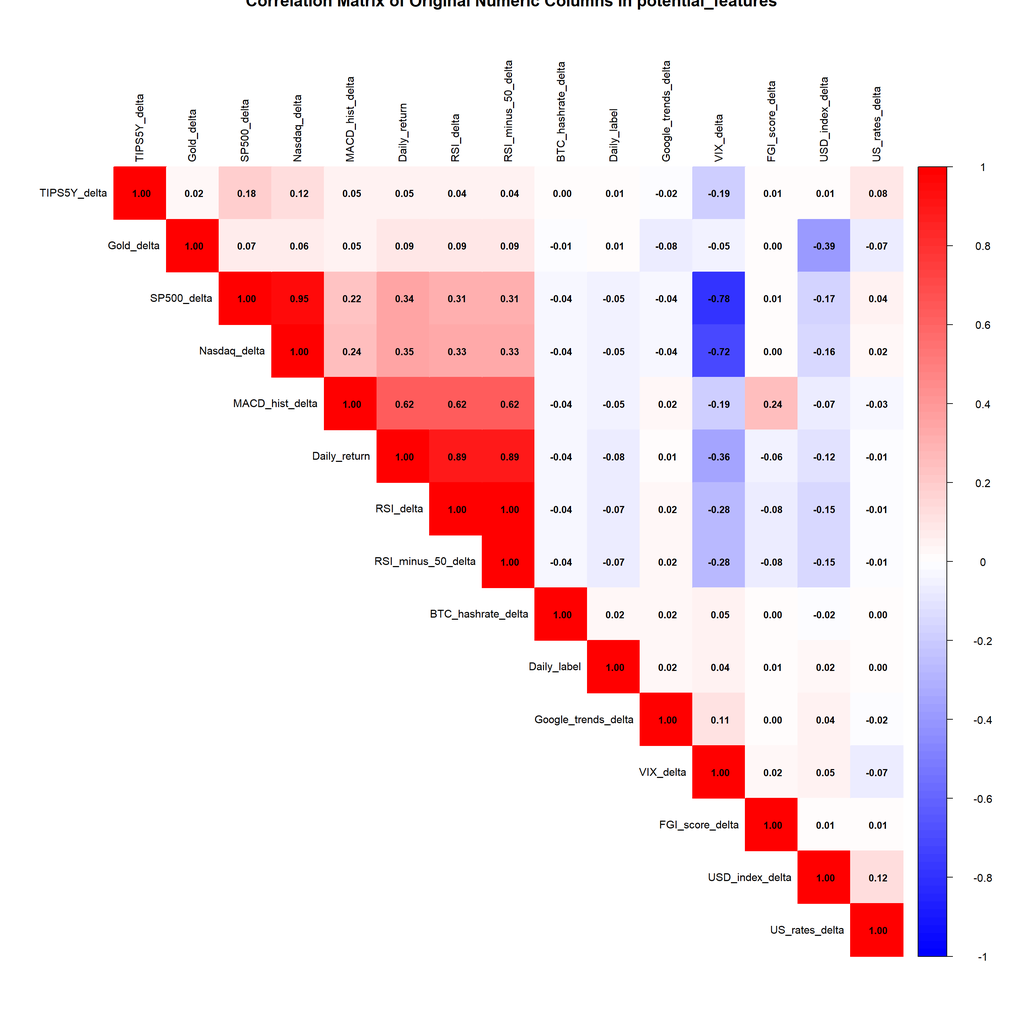

```r
# Identify potential features from low and medium autocorrelation columns
potential_features_list <- ac_summary %>%
  filter(Level %in% c("Low", "Medium") &
         !Column %in% c("Daily_fut_return", "Daily_label")) %>%
  pull(Column)

selected_cols <- c("Date", "Daily_label", potential_features_list)

# Only keep columns that exist in data
existing_cols <- selected_cols[selected_cols %in% names(data)]

# Now select from data
numeric_cols <- data %>%
  select(all_of(existing_cols)) %>%
  select_if(is.numeric)

# Compute the correlation matrix
corr_matrix <- cor(numeric_cols, use = "pairwise.complete.obs")

# Round the correlation matrix to 2 decimal places for readability
corr_matrix <- round(corr_matrix, 2)

# Set plot parameters to increase size and adjust margins
par(mar = c(12, 12, 4, 4), cex = 1.2)  # Larger margins and font size

# Create a correlation heatmap focusing on significant correlations
corrplot(corr_matrix, method = "color",
         type = "upper",
         order = "hclust",
         addCoef.col = "black",
         tl.col = "black",
         tl.srt = 90,  # Vertical labels
         tl.cex = 0.8,  # Slightly larger label text
         number.cex = 0.7,  # Larger coefficient text
         col = colorRampPalette(c("blue", "white", "red"))(100),
         diag = TRUE,
         sig.level = 0.9,  # Highlight correlations > 0.9
         insig = "blank",  # Blank out non-significant correlations
         title = "Correlation Matrix of Original Numeric Columns in potential_features")
```

From the results above, some correlations are too high. Therefore, some features have to be removed to avoid redundancy.

One has to choose between SP500_delta and Nasdaq_delta (difficult choice since they have the same correlation with the label, but I choose the Nasdaq_delta, because SP500_delta might have a too high correlation with the VIX_delta), and to keep only one between Daily_return, RSI_delta, and RSI_minus_50_delta (I keep Daily_return since it has the highest correlation with the label).

To resume, SP500_delta, RSI_delta and RSI_minus_50_delta are removed from potential features.

Now, we are going to add to the remaining features their lag 2 & 3 (features are already lag 1) that might add some signal to the model.

```r
# Identify potential features from low and medium autocorrelation columns
potential_features_list <- ac_summary %>%
  filter(Level %in% c("Low", "Medium") &
         !Column %in% c("Daily_fut_return", "Daily_label", "SP500_delta", "RSI_delta", "RSI_minus_50_delta")) %>%
  pull(Column)

# Initialize an empty Dataframe for the features, their lags, Date, and Daily_label
potential_features <- data.frame(row.names = 1:nrow(data))

# Add Date and Daily_label columns
potential_features$Date <- data$Date
potential_features$Daily_label <- data$Daily_label

# Add potential features and their lag +1 and +2
for (col in potential_features_list) {
  # Add original column
  potential_features[[col]] <- data[[col]]

  # Add lag 1 column
  lag1_col_name <- paste0(col, "_lag2")
  potential_features[[lag1_col_name]] <- lag(data[[col]], n = 1)

  # Add lag 2 column
  lag2_col_name <- paste0(col, "_lag3")
  potential_features[[lag2_col_name]] <- lag(data[[col]], n = 2)
}

# Drop the first two rows to handle NAs introduced by lagging
potential_features <- potential_features[-(1:2), ]

# Reset the index (row names) to start from 1
row.names(potential_features) <- NULL

# Print the Dataframe
head(potential_features, 2)
```

```
##         Date Daily_label Daily_return Daily_return_lag2 Daily_return_lag3
## 1 2019-12-20           0  0.005331438      -0.018021447        0.09948391
## 2 2019-12-21           1 -0.007429998       0.005331438       -0.01802145
##   Google_trends_delta Google_trends_delta_lag2 Google_trends_delta_lag3
## 1                  -4                       -8                        3
## 2                 -15                       -4                       -8
##   FGI_score_delta FGI_score_delta_lag2 FGI_score_delta_lag3 TIPS5Y_delta
## 1               2                    6                   -8         0.01
## 2               0                    2                    6         0.00
##   TIPS5Y_delta_lag2 TIPS5Y_delta_lag3 Nasdaq_delta Nasdaq_delta_lag2
## 1              0.02             -0.01     37.74023          59.47949
## 2              0.01              0.02      0.00000          37.74023
##   Nasdaq_delta_lag3 Gold_delta Gold_delta_lag2 Gold_delta_lag3 USD_index_delta
## 1          4.379883       -3.5        5.599976       -2.000000       0.2900009
## 2         59.479492        0.0       -3.500000        5.599976       0.0000000
##   USD_index_delta_lag2 USD_index_delta_lag3 US_rates_delta US_rates_delta_lag2
## 1          0.009994507          0.200004578   -0.004999995         0.014999986
## 2          0.290000916          0.009994507    0.000000000        -0.004999995
##   US_rates_delta_lag3  VIX_delta VIX_delta_lag2 VIX_delta_lag3 MACD_hist_delta
## 1         -0.01199996 0.01000023    -0.07999992     0.28999996       11.120996
## 2          0.01499999 0.00000000     0.01000023    -0.07999992        3.934511
##   MACD_hist_delta_lag2 MACD_hist_delta_lag3 BTC_hashrate_delta
## 1             12.22263             30.11152          -208531.2
## 2             11.12100             12.22263         12873561.4
##   BTC_hashrate_delta_lag2 BTC_hashrate_delta_lag3
## 1              14847397.0                -4480779
## 2               -208531.2                14847397
```

Now, we are going to perform a mutual information analysis…

```r
# Select numeric columns from potential_features (excluding Date and Daily_label)
numeric_cols <- potential_features %>%
  select_if(is.numeric) %>%
  select(-Daily_label)

# Discretize the numeric columns into bins for mutual information calculation
discretized_data <- discretize(numeric_cols, disc = "equalfreq", nbins = 5)

# Add the Daily_label column to the discretized data
discretized_data$Daily_label <- potential_features$Daily_label

# Compute mutual information between each feature and Daily_label
mi_results <- apply(discretized_data, 2, function(x) {
  mutinformation(x, discretized_data$Daily_label, method = "emp")
})

# Convert to data frame for better presentation, excluding Daily_label
mi_df <- data.frame(Feature = names(mi_results)[names(mi_results) != "Daily_label"],
                    Mutual_Information = mi_results[names(mi_results) != "Daily_label"])

# Sort by mutual information in descending order
mi_df <- mi_df[order(-mi_df$Mutual_Information), ]

# Print the results
print(mi_df)
```

```
##                                           Feature Mutual_Information
## Daily_return                         Daily_return       4.239917e-03
## Nasdaq_delta_lag3               Nasdaq_delta_lag3       2.415722e-03
## US_rates_delta_lag2           US_rates_delta_lag2       2.373253e-03
## TIPS5Y_delta_lag2               TIPS5Y_delta_lag2       1.744382e-03
## Nasdaq_delta                         Nasdaq_delta       1.532443e-03
## FGI_score_delta_lag3         FGI_score_delta_lag3       1.317143e-03
## MACD_hist_delta                   MACD_hist_delta       1.232769e-03
## Daily_return_lag2               Daily_return_lag2       1.229782e-03
## Gold_delta_lag2                   Gold_delta_lag2       1.001303e-03
## Google_trends_delta           Google_trends_delta       9.954096e-04
## Google_trends_delta_lag2 Google_trends_delta_lag2       9.662862e-04
## USD_index_delta_lag3         USD_index_delta_lag3       8.658010e-04
## BTC_hashrate_delta             BTC_hashrate_delta       8.330265e-04
## TIPS5Y_delta_lag3               TIPS5Y_delta_lag3       8.119345e-04
## Google_trends_delta_lag3 Google_trends_delta_lag3       7.313387e-04
## FGI_score_delta_lag2         FGI_score_delta_lag2       6.715914e-04
## BTC_hashrate_delta_lag2   BTC_hashrate_delta_lag2       6.022115e-04
## MACD_hist_delta_lag2         MACD_hist_delta_lag2       6.015383e-04
## US_rates_delta_lag3           US_rates_delta_lag3       5.721372e-04
## USD_index_delta_lag2         USD_index_delta_lag2       5.533009e-04
## Gold_delta_lag3                   Gold_delta_lag3       4.608548e-04
## MACD_hist_delta_lag3         MACD_hist_delta_lag3       4.478674e-04
## FGI_score_delta                   FGI_score_delta       3.668049e-04
## Nasdaq_delta_lag2               Nasdaq_delta_lag2       3.616821e-04
## BTC_hashrate_delta_lag3   BTC_hashrate_delta_lag3       2.804731e-04
## Gold_delta                             Gold_delta       2.726074e-04
## VIX_delta_lag3                     VIX_delta_lag3       2.055603e-04
## VIX_delta_lag2                     VIX_delta_lag2       1.959567e-04
## USD_index_delta                   USD_index_delta       1.868332e-04
## VIX_delta                               VIX_delta       1.764403e-04
## TIPS5Y_delta                         TIPS5Y_delta       1.217942e-04
## Daily_return_lag3               Daily_return_lag3       1.072154e-04
## US_rates_delta                     US_rates_delta       8.864953e-05
```

From the above analysis, we only keep the best 15 features.

Now we will use them for our first LightGBM model. The next step (and last for features selection) is to keep only the best features from the Features Importance analysis, that we obtain after having performed our first LightGBM model.

# 4 Machine Learning Model

Brief Presentation of LightGBM

LightGBM (Light Gradient Boosting Machine) is an advanced machine learning algorithm based on gradient boosting decision trees. Designed for speed and efficiency, it builds tree ensembles using a unique histogram-based approach and grows trees leaf-wise rather than level-wise. This makes LightGBM particularly effective for capturing complex, non-linear relationships in large and high-dimensional datasets. LightGBM supports both classification and regression, natively handles missing values and categorical variables, and is well suited for problems involving structured data—such as financial time series and trading signals—where fast training and high accuracy are crucial.

Model Selection and Justification

Given the classification task and dataset characteristics, several machine learning models are viable, but the recommendation leans toward LightGBM for the following reasons:

1. Efficiency and Performance: LightGBM is a gradient boosting framework known for its speed and efficiency, especially with structured data. It can handle the dataset size (1991 observations) effectively and capture non-linear relationships, which are common in financial data.
2. Feature Handling: With many features, LightGBM can manage high-dimensional data and provide feature importance, aiding in interpretation and potential feature selection.
3. Research Support: Studies like Deep learning for Bitcoin price direction prediction: models and trading strategies empirically compared (https://jfin-swufe.springeropen.com/articles/10.1186/s40854-024-00643-1) and Short-term bitcoin market prediction via machine learning (https://www.sciencedirect.com/science/article/pii/S2405918821000027) highlight LightGBM’s effectiveness in Bitcoin prediction, particularly for classification tasks.
4. Teacher’s Recommendation: The guidelines encourage trying new packages like LightGBM, which aligns with using tools not covered in class, potentially valued in the project.

## 4.1 Last step of Features Selection

```r
# Step 1: Feature selection based on mutual information or features importance
top_features <- mi_df %>%
  arrange(desc(Mutual_Information)) %>%
  head(15) %>%
  pull(Feature)

#top_features <- importance %>%
#  arrange(desc(Gain)) %>%
#  head(5) %>%
#  pull(Feature)

selected_features <- intersect(top_features, names(potential_features))

# Step 2: Set rolling window parameters (optimized)
train_size <- 400   # Reduced from 500 to speed up training
test_block <- 5     # Increased from 1 to predict 5 days per retrain
total_rows <- nrow(potential_features)
oos_start <- train_size + 1
if (oos_start > total_rows) stop("oos_start exceeds total_rows. Reduce train_size.")
oos_end <- total_rows

# Step 3: Prepare feature matrix (precomputed outside loop)
feature_matrix <- as.matrix(potential_features[, selected_features])

# Step 4: Set up parallel backend
num_cores <- parallel::detectCores() - 2 # Leave 2 cores free to reduce overhead
cl <- makeCluster(num_cores)
registerDoParallel(cl)

# Step 5: Indices for each parallel block
indices <- seq(oos_start, oos_end, by = test_block)

# Step 6: Parallel rolling walk-forward model and prediction
results_list <- foreach(idx = indices, .packages = c("lightgbm"), .errorhandling = "pass") %dopar% {
  # Training window
  train_idx <- (idx - train_size):(idx - 1)
  if (min(train_idx) < 1) {
    train_idx <- 1:max(1, idx - 1)
    if (length(train_idx) < train_size / 2) next  # Skip if too little training data
  }
  X_train <- feature_matrix[train_idx, , drop = FALSE]
  y_train <- potential_features$Daily_label[train_idx]

  # Test block indices
  test_indices <- idx:min(idx + test_block - 1, oos_end)
  if (max(test_indices) > nrow(feature_matrix)) {
    test_indices <- max(1, idx):nrow(feature_matrix)
  }
  X_test <- feature_matrix[test_indices, , drop = FALSE]

  dtrain <- lgb.Dataset(data = X_train, label = y_train)

  params <- list(
    objective = "binary",
    metric = "binary_error",
    boosting_type = "gbdt",
    verbosity = -1,
    num_leaves = 16,    # Kept the same
    learning_rate = 0.1, # Increased from 0.05 to speed up convergence
    feature_fraction = 0.8,
    bagging_fraction = 0.8,
    bagging_freq = 1,
    seed = 42
  )

  # Fit model with reduced rounds
  model <- lgb.train(
    params = params,
    data = dtrain,
    nrounds = 50,       # Reduced from 100 to speed up training
    verbose = -1
  )

  # Predict for test block
  pred_prob <- predict(model, X_test)
  pred <- ifelse(pred_prob > 0.5, 1, 0)

  # For feature importance, return model only for the last block
  is_last_block <- (idx == tail(indices, 1))
  list(
    indices = test_indices,
    preds = pred,
    model = if (is_last_block) model else NULL
  )
}

# Step 7: Stop cluster
stopCluster(cl)
registerDoSEQ()

# Step 8: Collect results
results <- data.frame(
  Date = potential_features$Date[oos_start:oos_end],
  Actual = potential_features$Daily_label[oos_start:oos_end],
  Pred = NA
)

for (res in results_list) {
  if (!is.null(res$indices) && !is.null(res$preds)) {
    rel_idx <- res$indices - oos_start + 1
    rel_idx <- rel_idx[rel_idx >= 1 & rel_idx <= nrow(results)]
    if (length(rel_idx) > 0) results$Pred[rel_idx] <- res$preds[1:length(rel_idx)]
  }
}

results <- results[!is.na(results$Pred), ]

# Step 9: Show confusion matrix and accuracy
if (nrow(results) > 0) {
  conf_matrix <- caret::confusionMatrix(
    factor(results$Pred, levels = c(0,1)),
    factor(results$Actual, levels = c(0,1))
  )
  print(conf_matrix)

  overall_acc <- mean(results$Pred == results$Actual, na.rm = TRUE)
  cat("Overall OOS Accuracy:", round(overall_acc, 4), "\n")
} else {
  cat("No valid predictions to compute confusion matrix or accuracy.\n")
}
```

```
## Confusion Matrix and Statistics
##
##           Reference
## Prediction   0   1
##          0 390 377
##          1 402 419
##
##                Accuracy : 0.5094
##                  95% CI : (0.4845, 0.5343)
##     No Information Rate : 0.5013
##     P-Value [Acc > NIR] : 0.2652
##
##                   Kappa : 0.0188
##
##  Mcnemar's Test P-Value : 0.3899
##
##             Sensitivity : 0.4924
##             Specificity : 0.5264
##          Pos Pred Value : 0.5085
##          Neg Pred Value : 0.5104
##              Prevalence : 0.4987
##          Detection Rate : 0.2456
##    Detection Prevalence : 0.4830
##       Balanced Accuracy : 0.5094
##
##        'Positive' Class : 0
##
## Overall OOS Accuracy: 0.5094
```

```r
# Step 10: Print feature importance from last LightGBM model
last_model <- NULL
for (res in rev(results_list)) {
  if (!is.null(res$model)) {
    last_model <- res$model
    break
  }
}
if (!is.null(last_model)) {
  importance <- lgb.importance(last_model, percentage = TRUE)
  print(importance)
}
```

```
##                      Feature       Gain      Cover  Frequency
##                       <char>      <num>      <num>      <num>
##  1:        Daily_return_lag2 0.13196436 0.13806867 0.13485114
##  2:       BTC_hashrate_delta 0.13027619 0.11639412 0.11908932
##  3:             Daily_return 0.09104551 0.08101475 0.08931699
##  4:             Nasdaq_delta 0.08651775 0.08748611 0.08231173
##  5:        Nasdaq_delta_lag3 0.07715623 0.07562841 0.07355517
##  6:     USD_index_delta_lag3 0.07569794 0.09771629 0.07705779
##  7:          MACD_hist_delta 0.07440937 0.06091607 0.08581436
##  8:          Gold_delta_lag2 0.05600953 0.05807435 0.05604203
##  9: Google_trends_delta_lag3 0.04908680 0.03925444 0.05253940
## 10:      Google_trends_delta 0.04822711 0.05998605 0.05078809
## 11:        TIPS5Y_delta_lag2 0.04300642 0.05111214 0.03677758
## 12: Google_trends_delta_lag2 0.04254531 0.03897027 0.04203152
## 13:      US_rates_delta_lag2 0.04118206 0.03906068 0.03327496
## 14:     FGI_score_delta_lag3 0.03682726 0.03766566 0.04903678
## 15:        TIPS5Y_delta_lag3 0.01604816 0.01865199 0.01751313
```

By having filtered the best features from the mutual analysis, then by features importance taking the best k-1, iteration after iteration, and finally by empirically trying set of potential best features thanks to previous analysis, it made me lead to the best top 7 features: “BTC_hashrate_delta”, “BTC_hashrate_delta_lag2”, “BTC_hashrate_delta_lag3”, “Daily_return”, “Daily_return_lag2”, “FGI_score_delta”, “FGI_score_delta_lag2”.

As you can see below, this best top 7 features gives a 53.78% of accuracy and a p-value < 1%. Therefore, we can confidently reject the null hypothesis and affirm this model has predictive power.

```r
# Step 1: Best features selection
best_features <- c("BTC_hashrate_delta", "BTC_hashrate_delta_lag2", "BTC_hashrate_delta_lag3",
                      "Daily_return", "Daily_return_lag2",
                      "FGI_score_delta", "FGI_score_delta_lag2")

# Ensure only features present in potential_features are used
best_features <- intersect(best_features, names(potential_features))

# Step 2: Set rolling window parameters (optimized)
train_size <- 400   # Reduced from 500 to speed up training
test_block <- 5     # Increased from 1 to predict 5 days per retrain
total_rows <- nrow(potential_features)
oos_start <- train_size + 1
if (oos_start > total_rows) stop("oos_start exceeds total_rows. Reduce train_size.")
oos_end <- total_rows

# Step 3: Prepare feature matrix (precomputed outside loop)
feature_matrix <- as.matrix(potential_features[, best_features])

# Step 4: Set up parallel backend
num_cores <- parallel::detectCores() - 2 # Leave 2 cores free to reduce overhead
cl <- makeCluster(num_cores)
registerDoParallel(cl)

# Step 5: Indices for each parallel block
indices <- seq(oos_start, oos_end, by = test_block)

# Step 6: Parallel rolling walk-forward model and prediction
results_list <- foreach(idx = indices, .packages = c("lightgbm"), .errorhandling = "pass") %dopar% {
  # Training window
  train_idx <- (idx - train_size):(idx - 1)
  if (min(train_idx) < 1) {
    train_idx <- 1:max(1, idx - 1)
    if (length(train_idx) < train_size / 2) next  # Skip if too little training data
  }
  X_train <- feature_matrix[train_idx, , drop = FALSE]
  y_train <- potential_features$Daily_label[train_idx]

  # Test block indices
  test_indices <- idx:min(idx + test_block - 1, oos_end)
  if (max(test_indices) > nrow(feature_matrix)) {
    test_indices <- max(1, idx):nrow(feature_matrix)
  }
  X_test <- feature_matrix[test_indices, , drop = FALSE]

  dtrain <- lgb.Dataset(data = X_train, label = y_train)

  params <- list(
    objective = "binary",
    metric = "binary_error",
    boosting_type = "gbdt",
    verbosity = -1,
    num_leaves = 16,    # Kept the same
    learning_rate = 0.1, # Increased from 0.05 to speed up convergence
    feature_fraction = 0.8,
    bagging_fraction = 0.8,
    bagging_freq = 1,
    seed = 42
  )

  # Fit model with reduced rounds
  model <- lgb.train(
    params = params,
    data = dtrain,
    nrounds = 50,       # Reduced from 100 to speed up training
    verbose = -1
  )

  # Predict for test block
  pred_prob <- predict(model, X_test)
  pred <- ifelse(pred_prob > 0.5, 1, 0)

  # For feature importance, return model only for the last block
  is_last_block <- (idx == tail(indices, 1))
  list(
    indices = test_indices,
    preds = pred,
    model = if (is_last_block) model else NULL
  )
}

# Step 7: Stop cluster
stopCluster(cl)
registerDoSEQ()

# Step 8: Collect results
results <- data.frame(
  Date = potential_features$Date[oos_start:oos_end],
  Actual = potential_features$Daily_label[oos_start:oos_end],
  Pred = NA
)

for (res in results_list) {
  if (!is.null(res$indices) && !is.null(res$preds)) {
    rel_idx <- res$indices - oos_start + 1
    rel_idx <- rel_idx[rel_idx >= 1 & rel_idx <= nrow(results)]
    if (length(rel_idx) > 0) results$Pred[rel_idx] <- res$preds[1:length(rel_idx)]
  }
}

results <- results[!is.na(results$Pred), ]

# Step 9: Show confusion matrix and accuracy
if (nrow(results) > 0) {
  conf_matrix <- caret::confusionMatrix(
    factor(results$Pred, levels = c(0,1)),
    factor(results$Actual, levels = c(0,1))
  )
  print(conf_matrix)

  overall_acc <- mean(results$Pred == results$Actual, na.rm = TRUE)
  cat("Overall OOS Accuracy:", round(overall_acc, 4), "\n")
} else {
  cat("No valid predictions to compute confusion matrix or accuracy.\n")
}
```

```
## Confusion Matrix and Statistics
##
##           Reference
## Prediction   0   1
##          0 405 347
##          1 387 449
##
##                Accuracy : 0.5378
##                  95% CI : (0.5129, 0.5625)
##     No Information Rate : 0.5013
##     P-Value [Acc > NIR] : 0.001944
##
##                   Kappa : 0.0754
##
##  Mcnemar's Test P-Value : 0.150004
##
##             Sensitivity : 0.5114
##             Specificity : 0.5641
##          Pos Pred Value : 0.5386
##          Neg Pred Value : 0.5371
##              Prevalence : 0.4987
##          Detection Rate : 0.2550
##    Detection Prevalence : 0.4736
##       Balanced Accuracy : 0.5377
##
##        'Positive' Class : 0
##
## Overall OOS Accuracy: 0.5378
```

```r
# Step 10: Print feature importance from last LightGBM model
last_model <- NULL
for (res in rev(results_list)) {
  if (!is.null(res$model)) {
    last_model <- res$model
    break
  }
}
if (!is.null(last_model)) {
  importance <- lgb.importance(last_model, percentage = TRUE)
  print(importance)
}
```

```
##                    Feature      Gain     Cover  Frequency
##                     <char>     <num>     <num>      <num>
## 1:      BTC_hashrate_delta 0.1615950 0.1538371 0.14834206
## 2:       Daily_return_lag2 0.1567061 0.1463542 0.16055846
## 3:            Daily_return 0.1547222 0.1415390 0.15532286
## 4: BTC_hashrate_delta_lag2 0.1528354 0.1530173 0.15357766
## 5: BTC_hashrate_delta_lag3 0.1424777 0.1536289 0.15532286
## 6:    FGI_score_delta_lag2 0.1252113 0.1378171 0.13089005
## 7:         FGI_score_delta 0.1064523 0.1138064 0.09598604
```

## 4.2 Parameters Analysis

Now that we have one of the most optimized set of features, the next step is to perform a hyper parameters analysis, to finally even more improve the predictive power of our LightGBM model.

We first perform this analysis on the size of the train period, by empirically changing its value and running the code and we obtained the graph below:

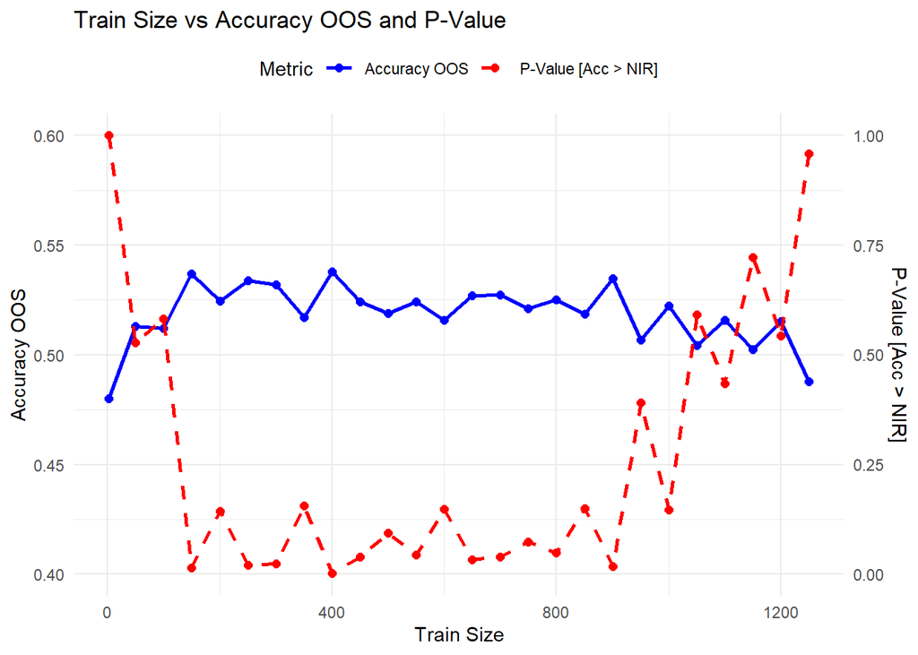

```r
# Create a dataframe from the provided table
data <- data.frame(
  Train_size = c(2, 50, 100, 150, 200, 250, 300, 350, 400, 450, 500, 550, 600, 650, 700, 750, 800, 850, 900, 950, 1000, 1050, 1100, 1150, 1200, 1250),
  Accuracy_OOS = c(0.4799, 0.5129, 0.5122, 0.537, 0.5246, 0.5339, 0.532, 0.5171, 0.5378, 0.5241, 0.5188, 0.5243, 0.5159, 0.5269, 0.5272, 0.521, 0.5253, 0.5185, 0.5349, 0.5067, 0.5223, 0.5043, 0.5158, 0.5024, 0.5152, 0.4878),
  P_Value = c(0.9989, 0.5273, 0.5822, 0.01497, 0.1435, 0.02067, 0.02428, 0.15551, 0.001944, 0.03923, 0.09305, 0.04323, 0.1476, 0.03348, 0.03956, 0.07359, 0.04907, 0.1497, 0.01819, 0.39, 0.1469, 0.5905, 0.43347, 0.7216, 0.5427, 0.9583)
)

# Create the dual-axis plot with adjusted Accuracy OOS range (0.4 to 0.6)
ggplot(data, aes(x = Train_size)) +
  # Line for Accuracy OOS (left y-axis)
  geom_line(aes(y = Accuracy_OOS, color = "Accuracy OOS"), size = 1) +
  geom_point(aes(y = Accuracy_OOS, color = "Accuracy OOS"), size = 2) +
  # Line for P-Value (right y-axis)
  geom_line(aes(y = P_Value * (0.6 - 0.4) / max(P_Value) + 0.4, color = "P-Value [Acc > NIR]"), size = 1, linetype = "dashed") +
  geom_point(aes(y = P_Value * (0.6 - 0.4) / max(P_Value) + 0.4, color = "P-Value [Acc > NIR]"), size = 2) +
  # Set scales with custom range for Accuracy OOS
  scale_y_continuous(name = "Accuracy OOS", limits = c(0.4, 0.6),
                     sec.axis = sec_axis(~ ((. - 0.4) * max(data$P_Value) / (0.6 - 0.4)), name = "P-Value [Acc > NIR]")) +
  # Customize colors and legend
  scale_color_manual(values = c("Accuracy OOS" = "blue", "P-Value [Acc > NIR]" = "red")) +
  labs(title = "Train Size vs Accuracy OOS and P-Value", x = "Train Size", color = "Metric") +
  theme_minimal() +
  theme(legend.position = "top")
```

Above results led me to take a train size of 400 observations. Then, we have to perform an analysis on hyper parameters.

I found that most critical hyper parameters are both num_leaves and learning_rate. Nonetheless nrounds, feature_fraction and bagging_fraction have an impact, it is more limited than the two previously mentioned.

In this way, and in order to minimize the computational time, we therefore below perform a grid search by exploring num_leaves and learning_rate only, with other hyper parameters being purposely fixed (but already on interesting values found empirically).

```r
# --- 1. Feature Selection ---
best_features <- c(
  "BTC_hashrate_delta", "BTC_hashrate_delta_lag2", "BTC_hashrate_delta_lag3",
  "Daily_return", "Daily_return_lag2",
  "FGI_score_delta", "FGI_score_delta_lag2"
)
best_features <- intersect(best_features, names(potential_features))

# --- 2. Prepare Feature Matrix ---
feature_matrix <- as.matrix(potential_features[, best_features])

# --- 3. Grid of Parameters ---
param_grid <- expand.grid(
  num_leaves = c(6, 8, 10, 12, 14, 16),
  learning_rate = c(0.025, 0.05, 0.075, 0.1),
  nrounds = c(50),
  feature_fraction = c(1.0),
  bagging_fraction = c(1.0)
)

# --- 4. Fixed Rolling Parameters ---
train_size <- 400
test_block <- 5
total_rows <- nrow(potential_features)
oos_start <- train_size + 1
oos_end <- total_rows

# --- 5. Store Results ---
results_list <- list()

for (i in 1:nrow(param_grid)) {
  params <- param_grid[i, ]
  cat(sprintf("\n=== Running combination %d of %d ===\n", i, nrow(param_grid)))
  cat(sprintf("Params: num_leaves=%d, learning_rate=%.3f, nrounds=%d, feature_fraction=%d, bagging_fraction=%d\n", params$num_leaves, params$learning_rate, params$nrounds, params$feature_fraction, params$bagging_fraction))

  # Parallel Backend
  num_cores <- parallel::detectCores() - 2
  cl <- makeCluster(num_cores)
  registerDoParallel(cl)

  indices <- seq(oos_start, oos_end, by = test_block)

  # Rolling Walk-Forward LightGBM
  res_list <- foreach(idx = indices, .packages = c("lightgbm"), .errorhandling = "pass") %dopar% {
    train_idx <- (idx - train_size):(idx - 1)
    if (min(train_idx) < 1) {
      train_idx <- 1:max(1, idx - 1)
      if (length(train_idx) < train_size / 2) next
    }
    X_train <- feature_matrix[train_idx, , drop = FALSE]
    y_train <- potential_features$Daily_label[train_idx]

    test_indices <- idx:min(idx + test_block - 1, oos_end)
    if (max(test_indices) > nrow(feature_matrix)) {
      test_indices <- max(1, idx):nrow(feature_matrix)
    }
    X_test <- feature_matrix[test_indices, , drop = FALSE]

    dtrain <- lgb.Dataset(data = X_train, label = y_train)

    lgb_params <- list(
      objective = "binary",
      metric = "binary_error",
      boosting_type = "gbdt",
      verbosity = -1,
      num_leaves = params$num_leaves,
      learning_rate = params$learning_rate,
      feature_fraction = params$feature_fraction,
      bagging_fraction = params$bagging_fraction,
      bagging_freq = 1,
      seed = 42
    )

    model <- lgb.train(
      params = lgb_params,
      data = dtrain,
      nrounds = params$nrounds,
      verbose = -1
    )

    pred_prob <- predict(model, X_test)
    pred <- ifelse(pred_prob > 0.5, 1, 0)
    list(
      indices = test_indices,
      preds = pred
    )
  }

  stopCluster(cl)
  registerDoSEQ()

  # Collect results
  results <- data.frame(
    Date = potential_features$Date[oos_start:oos_end],
    Actual = potential_features$Daily_label[oos_start:oos_end],
    Pred = NA
  )

  for (res in res_list) {
    if (!is.null(res$indices) && !is.null(res$preds)) {
      rel_idx <- res$indices - oos_start + 1
      rel_idx <- rel_idx[rel_idx >= 1 & rel_idx <= nrow(results)]
      if (length(rel_idx) > 0) results$Pred[rel_idx] <- res$preds[1:length(rel_idx)]
    }
  }

  results <- results[!is.na(results$Pred), ]

  # Compute accuracy
  overall_acc <- if (nrow(results) > 0) {
    mean(results$Pred == results$Actual, na.rm = TRUE)
  } else {
    NA
  }

  results_list[[i]] <- data.frame(
    Num_Leaves = params$num_leaves,
    Learning_Rate = params$learning_rate,
    N_Rounds = params$nrounds,
    Feature_Fraction = params$feature_fraction,
    Bagging_Fraction = params$bagging_fraction,
    OOS_Accuracy = round(overall_acc, 4)
  )

  cat(sprintf("OOS Accuracy for this run: %.4f\n", overall_acc))
}
```

```
##
## === Running combination 1 of 24 ===
## Params: num_leaves=6, learning_rate=0.025, nrounds=50, feature_fraction=1, bagging_fraction=1
## OOS Accuracy for this run: 0.5334
##
## === Running combination 2 of 24 ===
## Params: num_leaves=8, learning_rate=0.025, nrounds=50, feature_fraction=1, bagging_fraction=1
## OOS Accuracy for this run: 0.5403
##
## === Running combination 3 of 24 ===
## Params: num_leaves=10, learning_rate=0.025, nrounds=50, feature_fraction=1, bagging_fraction=1
## OOS Accuracy for this run: 0.5327
##
## === Running combination 4 of 24 ===
## Params: num_leaves=12, learning_rate=0.025, nrounds=50, feature_fraction=1, bagging_fraction=1
## OOS Accuracy for this run: 0.5416
##
## === Running combination 5 of 24 ===
## Params: num_leaves=14, learning_rate=0.025, nrounds=50, feature_fraction=1, bagging_fraction=1
## OOS Accuracy for this run: 0.5346
##
## === Running combination 6 of 24 ===
## Params: num_leaves=16, learning_rate=0.025, nrounds=50, feature_fraction=1, bagging_fraction=1
## OOS Accuracy for this run: 0.5422
##
## === Running combination 7 of 24 ===
## Params: num_leaves=6, learning_rate=0.050, nrounds=50, feature_fraction=1, bagging_fraction=1
## OOS Accuracy for this run: 0.5353
##
## === Running combination 8 of 24 ===
## Params: num_leaves=8, learning_rate=0.050, nrounds=50, feature_fraction=1, bagging_fraction=1
## OOS Accuracy for this run: 0.5409
##
## === Running combination 9 of 24 ===
## Params: num_leaves=10, learning_rate=0.050, nrounds=50, feature_fraction=1, bagging_fraction=1
## OOS Accuracy for this run: 0.5334
##
## === Running combination 10 of 24 ===
## Params: num_leaves=12, learning_rate=0.050, nrounds=50, feature_fraction=1, bagging_fraction=1
## OOS Accuracy for this run: 0.5378
```

[output cut: 41 more lines]

```
## === Running combination 21 of 24 ===
## Params: num_leaves=10, learning_rate=0.100, nrounds=50, feature_fraction=1, bagging_fraction=1
## OOS Accuracy for this run: 0.5321
##
## === Running combination 22 of 24 ===
## Params: num_leaves=12, learning_rate=0.100, nrounds=50, feature_fraction=1, bagging_fraction=1
## OOS Accuracy for this run: 0.5252
##
## === Running combination 23 of 24 ===
## Params: num_leaves=14, learning_rate=0.100, nrounds=50, feature_fraction=1, bagging_fraction=1
## OOS Accuracy for this run: 0.5321
##
## === Running combination 24 of 24 ===
## Params: num_leaves=16, learning_rate=0.100, nrounds=50, feature_fraction=1, bagging_fraction=1
## OOS Accuracy for this run: 0.5334
```

```r
# --- 6. Summarize Results ---
results_summary <- do.call(rbind, results_list)

# Show table
print(results_summary)
```

```
##    Num_Leaves Learning_Rate N_Rounds Feature_Fraction Bagging_Fraction
## 1           6         0.025       50                1                1
## 2           8         0.025       50                1                1
## 3          10         0.025       50                1                1
## 4          12         0.025       50                1                1
## 5          14         0.025       50                1                1
## 6          16         0.025       50                1                1
## 7           6         0.050       50                1                1
## 8           8         0.050       50                1                1
## 9          10         0.050       50                1                1
## 10         12         0.050       50                1                1
## 11         14         0.050       50                1                1
## 12         16         0.050       50                1                1
## 13          6         0.075       50                1                1
## 14          8         0.075       50                1                1
```

[output cut: 35 more lines]

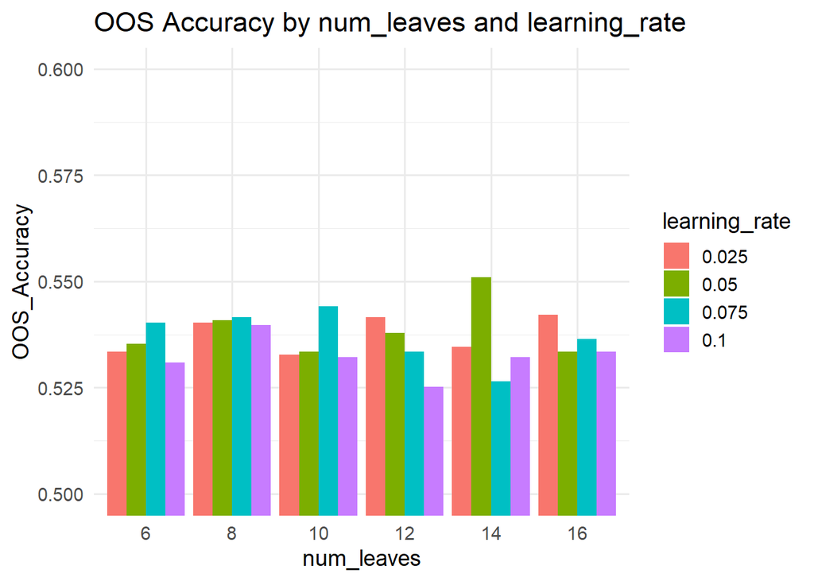

```r
# --- 7. Plotting ---

# Ensure correct types for plotting
results_summary$Num_Leaves <- as.factor(results_summary$Num_Leaves)
results_summary$Learning_Rate <- as.factor(results_summary$Learning_Rate)

# Bar plot
p_bar <- ggplot(results_summary, aes(x = Num_Leaves, y = OOS_Accuracy, fill = Learning_Rate)) +
  geom_bar(stat = "identity", position = "dodge") +
  labs(title = "OOS Accuracy by num_leaves and learning_rate",
       x = "num_leaves", fill = "learning_rate") +
  coord_cartesian(ylim = c(0.5, 0.6)) +
  theme_minimal(base_size = 14)
print(p_bar)
```

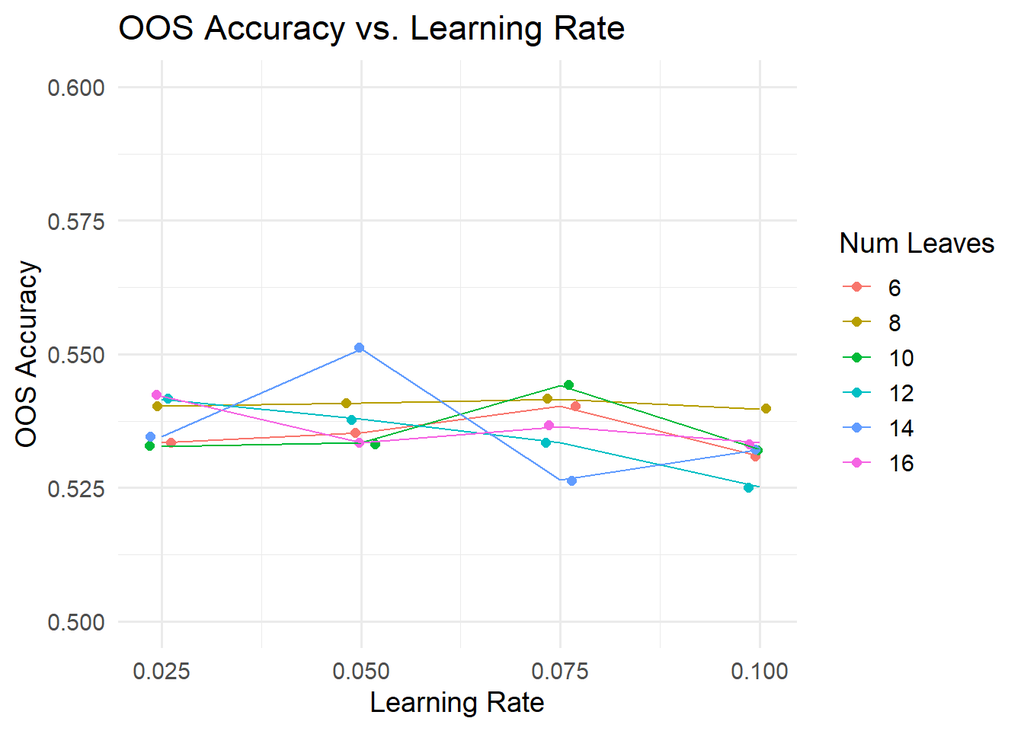

```r
# Scatter + line plot
p1 <- ggplot(results_summary, aes(x = as.numeric(as.character(Learning_Rate)), y = OOS_Accuracy,
                                  color = Num_Leaves, group = Num_Leaves)) +
  geom_point(position = position_jitter(width = 0.002), size = 2) +
  geom_line() +
  scale_x_continuous(breaks = sort(as.numeric(levels(results_summary$Learning_Rate)))) +
  labs(title = "OOS Accuracy vs. Learning Rate", x = "Learning Rate", y = "OOS Accuracy", color = "Num Leaves") +
  coord_cartesian(ylim = c(0.5, 0.6)) +
  theme_minimal(base_size = 14)
print(p1)
```

Best hyper parameters are the following: num_leaves = 14, learning_rate = 0.05, nrounds = 50, feature_fraction = 1, bagging_fraction = 1.

Now, we have an optimized set of features and optimized parameters for our model. This led us to the best accuracy we obtained which is 55.1%, and a p-value very close to zero, as one can see below.

```r
# Step 1: Best features selection
best_features <- c("BTC_hashrate_delta", "BTC_hashrate_delta_lag2", "BTC_hashrate_delta_lag3",
                      "Daily_return", "Daily_return_lag2",
                      "FGI_score_delta", "FGI_score_delta_lag2")

# Ensure only features present in potential_features are used
best_features <- intersect(best_features, names(potential_features))

# Step 2: Set rolling window parameters (optimized)
train_size <- 400   # Reduced from 500 to speed up training
test_block <- 5     # Increased from 1 to predict 5 days per retrain
total_rows <- nrow(potential_features)
oos_start <- train_size + 1
if (oos_start > total_rows) stop("oos_start exceeds total_rows. Reduce train_size.")
oos_end <- total_rows

# Step 3: Prepare feature matrix (precomputed outside loop)
feature_matrix <- as.matrix(potential_features[, best_features])

# Step 4: Set up parallel backend
num_cores <- parallel::detectCores() - 2 # Leave 2 cores free to reduce overhead
cl <- makeCluster(num_cores)
registerDoParallel(cl)

# Step 5: Indices for each parallel block
indices <- seq(oos_start, oos_end, by = test_block)

# Step 6: Parallel rolling walk-forward model and prediction
results_list <- foreach(idx = indices, .packages = c("lightgbm"), .errorhandling = "pass") %dopar% {
  # Training window
  train_idx <- (idx - train_size):(idx - 1)
  if (min(train_idx) < 1) {
    train_idx <- 1:max(1, idx - 1)
    if (length(train_idx) < train_size / 2) next  # Skip if too little training data
  }
  X_train <- feature_matrix[train_idx, , drop = FALSE]
  y_train <- potential_features$Daily_label[train_idx]

  # Test block indices
  test_indices <- idx:min(idx + test_block - 1, oos_end)
  if (max(test_indices) > nrow(feature_matrix)) {
    test_indices <- max(1, idx):nrow(feature_matrix)
  }
  X_test <- feature_matrix[test_indices, , drop = FALSE]

  dtrain <- lgb.Dataset(data = X_train, label = y_train)

  params <- list(
    objective = "binary",
    metric = "binary_error",
    boosting_type = "gbdt",
    verbosity = -1,
    num_leaves = 14,    # Kept the same
    learning_rate = 0.05, # Increased from 0.05 to speed up convergence
    feature_fraction = 1,
    bagging_fraction = 1,
    bagging_freq = 1,
    seed = 42
  )

  # Fit model with reduced rounds
  model <- lgb.train(
    params = params,
    data = dtrain,
    nrounds = 50,       # Reduced from 100 to speed up training
    verbose = -1
  )

  # Predict for test block
  pred_prob <- predict(model, X_test)
  pred <- ifelse(pred_prob > 0.5, 1, 0)

  # For feature importance, return model only for the last block
  is_last_block <- (idx == tail(indices, 1))
  list(
    indices = test_indices,
    preds = pred,
    model = if (is_last_block) model else NULL
  )
}

# Step 7: Stop cluster
stopCluster(cl)
registerDoSEQ()

# Step 8: Collect results
results <- data.frame(
  Date = potential_features$Date[oos_start:oos_end],
  Actual = potential_features$Daily_label[oos_start:oos_end],
  Pred = NA
)

for (res in results_list) {
  if (!is.null(res$indices) && !is.null(res$preds)) {
    rel_idx <- res$indices - oos_start + 1
    rel_idx <- rel_idx[rel_idx >= 1 & rel_idx <= nrow(results)]
    if (length(rel_idx) > 0) results$Pred[rel_idx] <- res$preds[1:length(rel_idx)]
  }
}

results <- results[!is.na(results$Pred), ]

# Step 9: Show confusion matrix and accuracy
if (nrow(results) > 0) {
  conf_matrix <- caret::confusionMatrix(
    factor(results$Pred, levels = c(0,1)),
    factor(results$Actual, levels = c(0,1))
  )
  print(conf_matrix)

  overall_acc <- mean(results$Pred == results$Actual, na.rm = TRUE)
  cat("Overall OOS Accuracy:", round(overall_acc, 4), "\n")
} else {
  cat("No valid predictions to compute confusion matrix or accuracy.\n")
}
```

```
## Confusion Matrix and Statistics
##
##           Reference
## Prediction   0   1
##          0 407 328
##          1 385 468
##
##                Accuracy : 0.551
##                  95% CI : (0.5262, 0.5757)
##     No Information Rate : 0.5013
##     P-Value [Acc > NIR] : 4.021e-05
##
##                   Kappa : 0.1018
##
##  Mcnemar's Test P-Value : 0.03597
##
##             Sensitivity : 0.5139
##             Specificity : 0.5879
##          Pos Pred Value : 0.5537
##          Neg Pred Value : 0.5487
##              Prevalence : 0.4987
##          Detection Rate : 0.2563
##    Detection Prevalence : 0.4628
##       Balanced Accuracy : 0.5509
##
##        'Positive' Class : 0
##
## Overall OOS Accuracy: 0.551
```

```r
# Step 10: Print feature importance from last LightGBM model
last_model <- NULL
for (res in rev(results_list)) {
  if (!is.null(res$model)) {
    last_model <- res$model
    break
  }
}
if (!is.null(last_model)) {
  importance <- lgb.importance(last_model, percentage = TRUE)
  print(importance)
}
```

```
##                    Feature       Gain     Cover  Frequency
##                     <char>      <num>     <num>      <num>
## 1:       Daily_return_lag2 0.19166712 0.1501783 0.16820988
## 2: BTC_hashrate_delta_lag2 0.18298065 0.1628646 0.17901235
## 3:      BTC_hashrate_delta 0.17010477 0.1537979 0.16358025
## 4: BTC_hashrate_delta_lag3 0.13142114 0.1064606 0.12808642
## 5:            Daily_return 0.13039856 0.1177520 0.14197531
## 6:    FGI_score_delta_lag2 0.11262114 0.2033159 0.13734568
## 7:         FGI_score_delta 0.08080663 0.1056307 0.08179012
```

# 5 Trading Strategy Backtesting

Finally, in the below section, we backtest a trading strategy powered by our LightGBM model’s predictions, carefully incorporating realistic transaction costs and various leverage levels, as available on the Binance BTC Perpetual Futures exchange.

```r
# --- FEE AND SIGNAL PREP ---
taker_fee <- 0.0005 # exact fee found on Binance
spread    <- 0.0004 # to be conservative
slippage  <- 0.0002 # to be conservative
funding   <- 0.0003 # to be conservative
fee_rate <- taker_fee + spread + slippage + funding

results$Signal <- ifelse(results$Pred == 1, 1, -1)
results$Signal <- dplyr::lag(results$Signal, 1)
results$Daily_Return <- potential_features$Daily_return[oos_start:oos_end][!is.na(results$Pred)]
bt_data <- results[!is.na(results$Signal) & !is.na(results$Daily_Return), ]
bt_data$Date <- as.Date(bt_data$Date)

# --- BACKTEST FUNCTION ---
backtest_with_fees <- function(leverage, bt_data, fee_rate) {
  strat_ret <- leverage * bt_data$Signal * bt_data$Daily_Return
  trade_occurred <- c(1, abs(diff(bt_data$Signal)))
  fee_paid <- abs(leverage) * fee_rate * trade_occurred
  net_strat_ret <- strat_ret - fee_paid
  portfolio_curve <- 100 * cumprod(1 + net_strat_ret)
  list(
    portfolio_curve = portfolio_curve,
    net_strat_ret = net_strat_ret,
    strat_ret = strat_ret
  )
}

# --- RUN BACKTESTS ---
buy_hold_curve <- 100 * cumprod(1 + bt_data$Daily_Return)
bt1   <- backtest_with_fees(1,   bt_data, fee_rate)
bt1_5 <- backtest_with_fees(1.5, bt_data, fee_rate)
bt2   <- backtest_with_fees(2,   bt_data, fee_rate)

# --- PERFORMANCE METRICS ---
ann_factor <- 365

return_fun <- function(x) {
  cumprod_ret <- prod(1 + x, na.rm=TRUE)
  n <- length(na.omit(x))
  (cumprod_ret)^(ann_factor / n) - 1
}
volatility_fun <- function(x) {
  sd(x, na.rm=TRUE) * sqrt(ann_factor)
}
investment_sharpe_fun <- function(x) {
  ann_return <- return_fun(x)
  ann_vol <- volatility_fun(x)
  if (ann_vol == 0) return(NA)
  ann_return / ann_vol
}

cat("\n--- Performance Summary ---\n")
```

```
##
## --- Performance Summary ---
```

```r
cat(sprintf(
  "No Leverage (x1):     Final Portfolio Value: $%.2f | Return: %.2f%% | Volatility: %.2f%% | Sharpe: %.2f\n",
  tail(bt1$portfolio_curve,1),
  100 * return_fun(bt1$net_strat_ret),
  100 * volatility_fun(bt1$net_strat_ret),
  investment_sharpe_fun(bt1$net_strat_ret)
))
```

```
## No Leverage (x1):     Final Portfolio Value: $715.22 | Return: 57.18% | Volatility: 59.96% | Sharpe: 0.95
```

```r
cat(sprintf(
  "Leverage x1.5:        Final Portfolio Value: $%.2f | Return: %.2f%% | Volatility: %.2f%% | Sharpe: %.2f\n",
  tail(bt1_5$portfolio_curve,1),
  100 * return_fun(bt1_5$net_strat_ret),
  100 * volatility_fun(bt1_5$net_strat_ret),
  investment_sharpe_fun(bt1_5$net_strat_ret)
))
```

```
## Leverage x1.5:        Final Portfolio Value: $1069.40 | Return: 72.40% | Volatility: 89.93% | Sharpe: 0.81
```

```r
cat(sprintf(
  "Leverage x2:          Final Portfolio Value: $%.2f | Return: %.2f%% | Volatility: %.2f%% | Sharpe: %.2f\n",
  tail(bt2$portfolio_curve,1),
  100 * return_fun(bt2$net_strat_ret),
  100 * volatility_fun(bt2$net_strat_ret),
  investment_sharpe_fun(bt2$net_strat_ret)
))
```

```
## Leverage x2:          Final Portfolio Value: $1082.01 | Return: 72.87% | Volatility: 119.91% | Sharpe: 0.61
```

```r
cat(sprintf(
  "Buy & Hold:           Final Portfolio Value: $%.2f | Return: %.2f%% | Volatility: %.2f%% | Sharpe: %.2f\n",
  tail(buy_hold_curve,1),
  100 * return_fun(bt_data$Daily_Return),
  100 * volatility_fun(bt_data$Daily_Return),
  investment_sharpe_fun(bt_data$Daily_Return)
))
```

```
## Buy & Hold:           Final Portfolio Value: $325.82 | Return: 31.19% | Volatility: 60.11% | Sharpe: 0.52
```

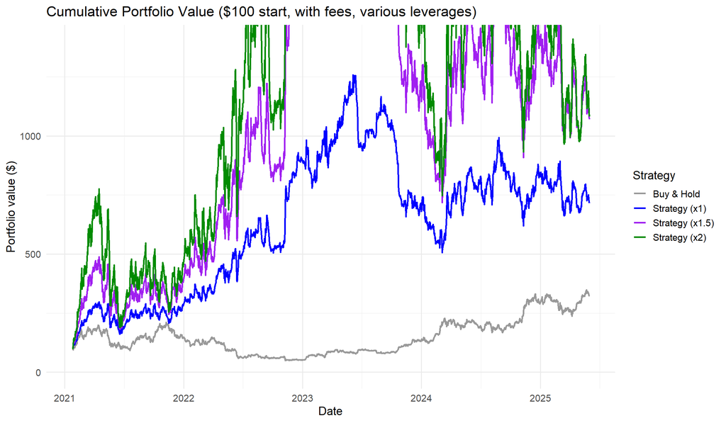

```r
# --- PLOTTING ---
df_plot <- data.frame(
  Date = bt_data$Date,
  Buy_and_Hold   = buy_hold_curve,
  Strategy_x1    = bt1$portfolio_curve,
  Strategy_x1_5  = bt1_5$portfolio_curve,
  Strategy_x2    = bt2$portfolio_curve
)

colnames(df_plot) <- c("Date", "Buy & Hold", "Strategy (x1)", "Strategy (x1.5)", "Strategy (x2)")

df_plot_long <- tidyr::pivot_longer(
  df_plot,
  cols = c("Buy & Hold", "Strategy (x1)", "Strategy (x1.5)", "Strategy (x2)"),
  names_to = "Strategy",
  values_to = "Portfolio_value"
)

p <- ggplot(df_plot_long, aes(x = Date, y = Portfolio_value, color = Strategy)) +
  geom_line(size = 1) +
  labs(title = "Cumulative Portfolio Value ($100 start, with fees, various leverages)",
       y = "Portfolio value ($)",
       x = "Date") +
  scale_color_manual(values = c(
    "Buy & Hold" = "gray60",
    "Strategy (x1)" = "blue",
    "Strategy (x1.5)" = "purple",
    "Strategy (x2)" = "green4"
  )) +
  coord_cartesian(ylim = c(0, 1400)) +
  theme_minimal(base_size = 14) +
  theme(legend.position = "right")
print(p)
```

The above results of our backtesting lead us to conclude that our machine learning-based trading strategy on Bitcoin outperforms the buy-and-hold strategy over the out-of-sample period.